# US Healthcare Spending and Coverage

Sept 17, 2018

# Motivation

In the last lecture, we were analyzing health care data in the United States. We were exploring the following questions:

1. Is there a relationship between healthcare coverage and healthcare spending in the United States?
2. Which US states spend the most and which spend the least on healthcare? How does the spending distribution change across geographic regions in the United States?
3. How do healthcare coverage and spending relate to life expectancy?

## Healthcare data

The data is from the [Henry J Kaiser Family Foundation (KFF)](https://www.kff.org).

- [Health Insurance Coverage of the Total Population](https://www.kff.org/other/state-indicator/total-population/) - Includes years 2013-2016
- [Health Care Expenditures by State of Residence (in millions)](https://www.kff.org/other/state-indicator/health-care-expenditures-by-state-of-residence-in-millions/) - Includes years 1991-2014
- [Life Expectancy at Birth (in years)](https://www.kff.org/other/state-indicator/life-expectancy)

## Re-cap from last time

Let’s recall what we did before:

Load in the `tidyverse` of R package

```r
library(tidyverse)
```

Read in the datasets with the `readr` R package

```r
coverage <- read_csv("../data/KFF/healthcare-coverage.csv",
                     skip = 2, col_names = TRUE)
coverage <- read_csv("../data/KFF/healthcare-coverage.csv",
                     skip = 2, col_names = TRUE,
                     n_max  = which(coverage$Location == "Notes")-1)
spending <- read_csv("../data/KFF/healthcare-spending.csv",
                     skip = 2, col_names = TRUE)
spending <- read_csv("../data/KFF/healthcare-spending.csv",
                     skip = 2, col_names = TRUE,
                     n_max  = which(spending$Location == "Notes")-1)
life <- read_csv("../data/KFF/life-expectancy.csv",
                     skip = 2, col_names = TRUE)
life <- read_csv("../data/KFF/life-expectancy.csv",
                     skip = 2, col_names = TRUE,
                     n_max  = which(life$Location == "Sources")-1)
```

Convert the `coverage` and `spending` datasets from *wide* to *long* formats using the `tidyr` R package

```r
coverage <- gather(coverage, "year_type", "tot_coverage", -Location)
spending <- gather(spending, "year", "tot_spending", -Location)
```

Wrangle the datasets using some `dplyr` action verbs

```r
coverage <-
  coverage %>%
  separate(year_type, sep="__", into=c("year", "type"), convert = TRUE) %>%
  mutate_at("tot_coverage", as.integer)

spending <-
  spending %>%
  separate(year, sep="__", into=c("year", "name"), convert = TRUE) %>%
  select(-name)

life <-
  life %>%
  rename(life_exp_years = `Life Expectancy at Birth (years)`)
```

Now we will continue to learn more about data wrangling using the `dplyr` package, including how to join two datasets together, how to summarize columns of data, and how to apply group operations using the “split-apply-combine” concept.

We will also start an introduction to the `ggplot2` package for data visualization.

# Data Wrangling

Before we dive back into data wrangling with `dplyr`, it would be nice add some information about each state. Namely, the state abbreviation and state region (i.e. north, south, etc).

For this we use the [state](https://stat.ethz.ch/R-manual/R-devel/library/datasets/html/state.html) dataset in the `datasets` R package.

Before we begin, let’s look at what states are there:

```r
unique(coverage$Location)
```

```
##  [1] "United States"        "Alabama"              "Alaska"
##  [4] "Arizona"              "Arkansas"             "California"
##  [7] "Colorado"             "Connecticut"          "Delaware"
## [10] "District of Columbia" "Florida"              "Georgia"
## [13] "Hawaii"               "Idaho"                "Illinois"
## [16] "Indiana"              "Iowa"                 "Kansas"
## [19] "Kentucky"             "Louisiana"            "Maine"
## [22] "Maryland"             "Massachusetts"        "Michigan"
## [25] "Minnesota"            "Mississippi"          "Missouri"
## [28] "Montana"              "Nebraska"             "Nevada"
## [31] "New Hampshire"        "New Jersey"           "New Mexico"
## [34] "New York"             "North Carolina"       "North Dakota"
## [37] "Ohio"                 "Oklahoma"             "Oregon"
## [40] "Pennsylvania"         "Rhode Island"         "South Carolina"
## [43] "South Dakota"         "Tennessee"            "Texas"
## [46] "Utah"                 "Vermont"              "Virginia"
## [49] "Washington"           "West Virginia"        "Wisconsin"
## [52] "Wyoming"
```

We see there are more than 50 states because “United States” and “District of Columbia” are both included.

Let’s look what states are inside the `state` dataset.

```r
library(datasets)
data(state)
unique(state.name)
```

```
##  [1] "Alabama"        "Alaska"         "Arizona"        "Arkansas"
##  [5] "California"     "Colorado"       "Connecticut"    "Delaware"
##  [9] "Florida"        "Georgia"        "Hawaii"         "Idaho"
## [13] "Illinois"       "Indiana"        "Iowa"           "Kansas"
## [17] "Kentucky"       "Louisiana"      "Maine"          "Maryland"
## [21] "Massachusetts"  "Michigan"       "Minnesota"      "Mississippi"
## [25] "Missouri"       "Montana"        "Nebraska"       "Nevada"
## [29] "New Hampshire"  "New Jersey"     "New Mexico"     "New York"
## [33] "North Carolina" "North Dakota"   "Ohio"           "Oklahoma"
## [37] "Oregon"         "Pennsylvania"   "Rhode Island"   "South Carolina"
## [41] "South Dakota"   "Tennessee"      "Texas"          "Utah"
## [45] "Vermont"        "Virginia"       "Washington"     "West Virginia"
## [49] "Wisconsin"      "Wyoming"
```

Ah, ok. So let’s start by dealing with DC as a special case.

```r
state.abb <- c(state.abb, "DC")
state.region <- as.factor(c(as.character(state.region), "South"))
state.name <- c(state.name, "District of Columbia")
coverage$abb <- state.abb[match(coverage$Location, state.name)]
coverage$region <- state.region[match(coverage$Location, state.name)]

coverage
```

```
## # A tibble: 1,456 x 6
##    Location              year type     tot_coverage abb   region
##    <chr>                <int> <chr>           <int> <chr> <fct>
##  1 United States         2013 Employer    155696900 <NA>  <NA>
##  2 Alabama               2013 Employer      2126500 AL    South
##  3 Alaska                2013 Employer       364900 AK    West
##  4 Arizona               2013 Employer      2883800 AZ    West
##  5 Arkansas              2013 Employer      1128800 AR    South
##  6 California            2013 Employer     17747300 CA    West
##  7 Colorado              2013 Employer      2852500 CO    West
##  8 Connecticut           2013 Employer      2030500 CT    Northeast
##  9 Delaware              2013 Employer       473700 DE    South
## 10 District of Columbia  2013 Employer       324300 DC    South
## # ... with 1,446 more rows
```

We will deal with the “United States” in the next section.

## The `dplyr` R package

### Join two datasets together

Up until now, we have been working with three datasets `coverage`, `spending`, and `life` separtely. Next, we will combine these together.

If we want to combine, say, `coverage` and `spending` together, we have to decide a few things. Both share a `Location` column and a `year` column. However, the range of `years` is different between datasets.

```r
table(coverage$year)
```

```
##
## 2013 2014 2015 2016
##  364  364  364  364
```

```r
table(spending$year)
```

```
##
## 1991 1992 1993 1994 1995 1996 1997 1998 1999 2000 2001 2002 2003 2004 2005
##   52   52   52   52   52   52   52   52   52   52   52   52   52   52   52
## 2006 2007 2008 2009 2010 2011 2012 2013 2014
##   52   52   52   52   52   52   52   52   52
```

Do we want a dataset with all the years available or only a portion of it? Because there is spending information from 1991-2014, and coverage information from 2013-2016.

`dplyr` has a list of `join` functions that are useful to combine datasets. To read more about them, Jenny Bryan has created a nice [cheatsheet](http://stat545.com/bit001_dplyr-cheatsheet.html).

If we look at the help file

```r
?dplyr::join
```

We see there are several options for us to pick from. Let’s try one out. We’ll start with `left_join()` and see what that does.

```r
hc <- left_join(coverage, spending, by = c("Location", "year"))
head(hc)
```

```
## # A tibble: 6 x 7
##   Location       year type     tot_coverage abb   region tot_spending
##   <chr>         <int> <chr>           <int> <chr> <fct>         <int>
## 1 United States  2013 Employer    155696900 <NA>  <NA>        2435624
## 2 Alabama        2013 Employer      2126500 AL    South         33788
## 3 Alaska         2013 Employer       364900 AK    West           7684
## 4 Arizona        2013 Employer      2883800 AZ    West          41481
## 5 Arkansas       2013 Employer      1128800 AR    South         20500
## 6 California     2013 Employer     17747300 CA    West         278168
```

```r
tail(hc)
```

```
## # A tibble: 6 x 7
##   Location       year type  tot_coverage abb   region        tot_spending
##   <chr>         <int> <chr>        <int> <chr> <fct>                <int>
## 1 Vermont        2016 Total       622500 VT    Northeast               NA
## 2 Virginia       2016 Total      8175000 VA    South                   NA
## 3 Washington     2016 Total      7297300 WA    West                    NA
## 4 West Virginia  2016 Total      1814100 WV    South                   NA
## 5 Wisconsin      2016 Total      5766100 WI    North Central           NA
## 6 Wyoming        2016 Total       571700 WY    West                    NA
```

What did it do? We see that the new `hc` dataset includes all the years from 2013-2016 (as that is the range of years in `coverage`), but because the `spending` dataset only goes to 2014, the `tot_spending` is reported as NA for years 2015 and 2016.

What about a `right_join()`?

```r
hc <- right_join(coverage, spending, by = c("Location", "year"))
head(hc)
```

```
## # A tibble: 6 x 7
##   Location       year type  tot_coverage abb   region tot_spending
##   <chr>         <int> <chr>        <int> <chr> <fct>         <int>
## 1 United States  1991 <NA>            NA <NA>  <NA>         675896
## 2 Alabama        1991 <NA>            NA <NA>  <NA>          10393
## 3 Alaska         1991 <NA>            NA <NA>  <NA>           1458
## 4 Arizona        1991 <NA>            NA <NA>  <NA>           9269
## 5 Arkansas       1991 <NA>            NA <NA>  <NA>           5632
## 6 California     1991 <NA>            NA <NA>  <NA>          81438
```

```r
tail(hc)
```

```
## # A tibble: 6 x 7
##   Location  year type         tot_coverage abb   region tot_spending
##   <chr>    <int> <chr>               <int> <chr> <fct>         <int>
## 1 Wyoming   2014 Non-Group           31600 WY    West           4856
## 2 Wyoming   2014 Medicaid            54900 WY    West           4856
## 3 Wyoming   2014 Medicare            65600 WY    West           4856
## 4 Wyoming   2014 Other Public        13600 WY    West           4856
## 5 Wyoming   2014 Uninsured           58100 WY    West           4856
## 6 Wyoming   2014 Total              572000 WY    West           4856
```

Here, we see every row in the spending dataset is there, but with NAs for the years that there was no coverage data.

There is also a `full_join()` and `inner_join()`. If we want the intersection of `years` from `coverage` and `spending` (meaning only 2013 and 2014), we should use `inner_join()`.

```r
hc <- inner_join(coverage, spending, by = c("Location", "year"))
head(hc)
```

```
## # A tibble: 6 x 7
##   Location       year type     tot_coverage abb   region tot_spending
##   <chr>         <int> <chr>           <int> <chr> <fct>         <int>
## 1 United States  2013 Employer    155696900 <NA>  <NA>        2435624
## 2 Alabama        2013 Employer      2126500 AL    South         33788
## 3 Alaska         2013 Employer       364900 AK    West           7684
## 4 Arizona        2013 Employer      2883800 AZ    West          41481
## 5 Arkansas       2013 Employer      1128800 AR    South         20500
## 6 California     2013 Employer     17747300 CA    West         278168
```

```r
tail(hc)
```

```
## # A tibble: 6 x 7
##   Location       year type  tot_coverage abb   region        tot_spending
##   <chr>         <int> <chr>        <int> <chr> <fct>                <int>
## 1 Vermont        2014 Total       617000 VT    Northeast             6389
## 2 Virginia       2014 Total      8258800 VA    South                62847
## 3 Washington     2014 Total      7085000 WA    West                 55819
## 4 West Virginia  2014 Total      1825500 WV    South                17491
## 5 Wisconsin      2014 Total      5747200 WI    North Central        50109
## 6 Wyoming        2014 Total       572000 WY    West                  4856
```

Yes, that’s what we want!

Next, let’s combine our new `hc` dataset with the `life` dataset.

```r
colnames(hc)
```

```
## [1] "Location"     "year"         "type"         "tot_coverage"
## [5] "abb"          "region"       "tot_spending"
```

```r
colnames(life)
```

```
## [1] "Location"       "life_exp_years"
```

In this case, the only column variable that is shared between these two is the `Location` column. So we can use

```r
hc <- left_join(hc, life, by = c("Location"))
hc
```

```
## # A tibble: 728 x 8
##    Location          year type    tot_coverage abb   region   tot_spending
##    <chr>            <int> <chr>          <int> <chr> <fct>           <int>
##  1 United States     2013 Employ…    155696900 <NA>  <NA>          2435624
##  2 Alabama           2013 Employ…      2126500 AL    South           33788
##  3 Alaska            2013 Employ…       364900 AK    West             7684
##  4 Arizona           2013 Employ…      2883800 AZ    West            41481
##  5 Arkansas          2013 Employ…      1128800 AR    South           20500
##  6 California        2013 Employ…     17747300 CA    West           278168
##  7 Colorado          2013 Employ…      2852500 CO    West            34090
##  8 Connecticut       2013 Employ…      2030500 CT    Northea…        34223
##  9 Delaware          2013 Employ…       473700 DE    South            9038
## 10 District of Col…  2013 Employ…       324300 DC    South            7443
## # ... with 718 more rows, and 1 more variable: life_exp_years <dbl>
```

Finally, if we are only interested in looking at US states, we can remove the rows corresponding to the `Location == "United States"`

```r
hc <- hc %>%
  filter(Location != "United States")
```

Another problem is that inside our `hc` dataset, we have seen there are multiple `types` of healthcare coverage

```r
table(hc$type)
```

```
##
##     Employer     Medicaid     Medicare    Non-Group Other Public
##          102          102          102          102          102
##        Total    Uninsured
##          102          102
```

The `total` type is not really a formal type of healthcare coverage. It really represents just the total number of people in the state. This is useful information and we can include it as a column called `tot_pop`. How can we do this?

Well, one way would be to use the `join` functions again in `dplyr`.

```r
pop <- hc %>%
  filter(type == "Total") %>%
  select(Location, year, tot_coverage)
pop
```

```
## # A tibble: 102 x 3
##    Location              year tot_coverage
##    <chr>                <int>        <int>
##  1 Alabama               2013      4763900
##  2 Alaska                2013       702000
##  3 Arizona               2013      6603100
##  4 Arkansas              2013      2904800
##  5 California            2013     38176400
##  6 Colorado              2013      5297800
##  7 Connecticut           2013      3578900
##  8 Delaware              2013       909300
##  9 District of Columbia  2013       652100
## 10 Florida               2013     19429000
## # ... with 92 more rows
```

```r
hc <- hc %>%
  filter(type != "Total") %>%
  left_join(pop, by = c("Location", "year")) %>%
  rename(tot_coverage = tot_coverage.x, tot_pop = tot_coverage.y)
hc
```

```
## # A tibble: 612 x 9
##    Location          year type    tot_coverage abb   region   tot_spending
##    <chr>            <int> <chr>          <int> <chr> <fct>           <int>
##  1 Alabama           2013 Employ…      2126500 AL    South           33788
##  2 Alaska            2013 Employ…       364900 AK    West             7684
##  3 Arizona           2013 Employ…      2883800 AZ    West            41481
##  4 Arkansas          2013 Employ…      1128800 AR    South           20500
##  5 California        2013 Employ…     17747300 CA    West           278168
##  6 Colorado          2013 Employ…      2852500 CO    West            34090
##  7 Connecticut       2013 Employ…      2030500 CT    Northea…        34223
##  8 Delaware          2013 Employ…       473700 DE    South            9038
##  9 District of Col…  2013 Employ…       324300 DC    South            7443
## 10 Florida           2013 Employ…      8023400 FL    South          150547
## # ... with 602 more rows, and 2 more variables: life_exp_years <dbl>,
## #   tot_pop <int>
```

We can check to make sure that the `total` is no longer listed as a `type` of healthcare coverage.

```r
table(hc$type)
```

```
##
##     Employer     Medicaid     Medicare    Non-Group Other Public
##          102          102          102          102          102
##    Uninsured
##          102
```

We are now ready to try answering our first question that we asked:

> 1. Is there a relationship between healthcare coverage and healthcare spending in the United States?

Let’s pick out the `type==Employer` and `year==2013`.

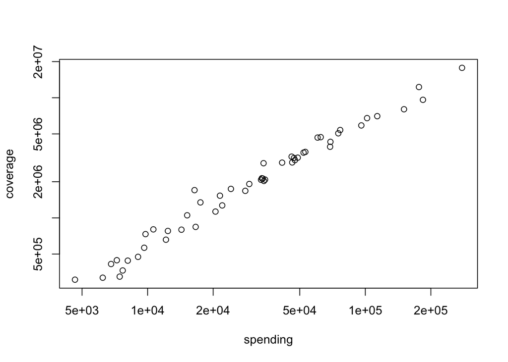

```r
hc.employer.2013 <- hc %>%
  filter(type == "Employer", year == "2013")
plot(hc.employer.2013$tot_spending,
     hc.employer.2013$tot_coverage, log = "xy",
     xlab = "spending", ylab = "coverage")
```

We see there is a strong relationship. However, we also see that healthcare coverage and spending is also strongly related to population size

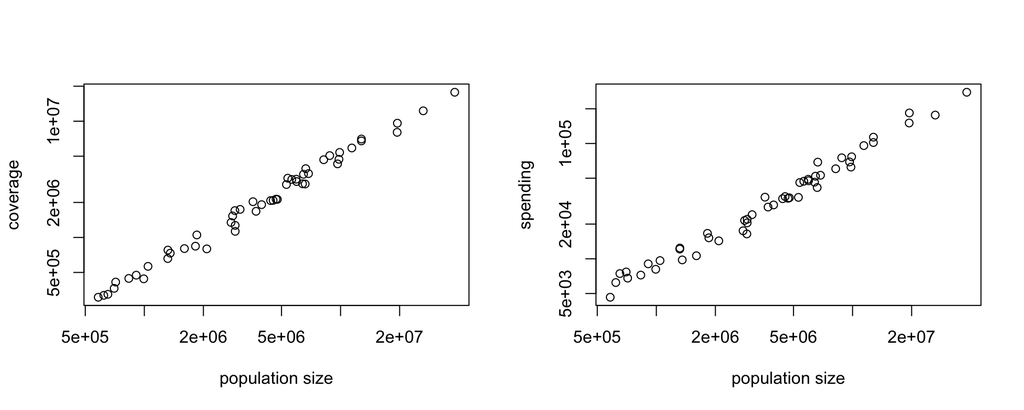

```r
par(mfrow=c(1,2))
plot(hc.employer.2013$tot_pop,
     hc.employer.2013$tot_coverage, log = "xy",
     xlab = "population size", ylab = "coverage")
plot(hc.employer.2013$tot_pop,
     hc.employer.2013$tot_spending, log = "xy",
     xlab = "population size", ylab = "spending")
```

This means we need to take into account the population size of each state when we are comparing the heathcare coverage and spending.

### Add columns using `mutate()`

Instead of the absolute number of people who are covered (`tot_coverage`), we will calculate the proportion of people who are coverage in each state, year and type.

For this, we will use the `mutate()` function in `dplyr`.

```r
hc <- hc %>%
    mutate(prop_coverage = tot_coverage/tot_pop)
hc
```

```
## # A tibble: 612 x 10
##    Location          year type    tot_coverage abb   region   tot_spending
##    <chr>            <int> <chr>          <int> <chr> <fct>           <int>
##  1 Alabama           2013 Employ…      2126500 AL    South           33788
##  2 Alaska            2013 Employ…       364900 AK    West             7684
##  3 Arizona           2013 Employ…      2883800 AZ    West            41481
##  4 Arkansas          2013 Employ…      1128800 AR    South           20500
##  5 California        2013 Employ…     17747300 CA    West           278168
##  6 Colorado          2013 Employ…      2852500 CO    West            34090
##  7 Connecticut       2013 Employ…      2030500 CT    Northea…        34223
##  8 Delaware          2013 Employ…       473700 DE    South            9038
##  9 District of Col…  2013 Employ…       324300 DC    South            7443
## 10 Florida           2013 Employ…      8023400 FL    South          150547
## # ... with 602 more rows, and 3 more variables: life_exp_years <dbl>,
## #   tot_pop <int>, prop_coverage <dbl>
```

We need to add another column to our dataset. We will add the spending per capita (or spending per person) in dollars and name this column `spending_capita`.

How we will do this?

The `tot_spending` column is reported in millions (1e6). Therefore, to calculate `spending_capita` we will need to adjust for this scaling factor to report it on the original scale (just dollars) and then divide by `tot_pop`.

```r
hc <- hc %>%
    mutate(spending_capita = (tot_spending*1e6) / tot_pop)
hc %>% select(prop_coverage, spending_capita)
```

```
## # A tibble: 612 x 2
##    prop_coverage spending_capita
##            <dbl>           <dbl>
##  1         0.446           7093.
##  2         0.520          10946.
##  3         0.437           6282.
##  4         0.389           7057.
##  5         0.465           7286.
##  6         0.538           6435.
##  7         0.567           9562.
##  8         0.521           9940.
##  9         0.497          11414.
## 10         0.413           7749.
## # ... with 602 more rows
```

Now we are ready to go back to our first question

> 1. Is there a relationship between healthcare coverage and healthcare spending in the United States?

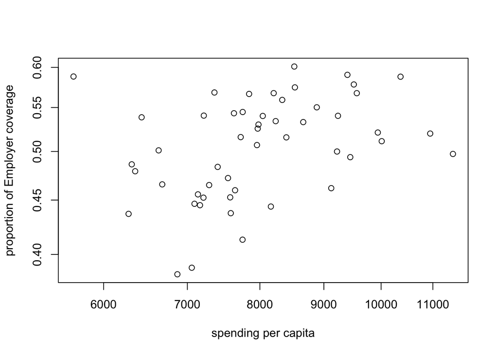

```r
hc.employer.2013 <- hc %>%
  filter(type == "Employer", year == "2013")
plot(hc.employer.2013$spending_capita,
     hc.employer.2013$prop_coverage, log = "xy",
     xlab = "spending per capita",
     ylab = "proportion of Employer coverage")
```

Yes, it looks like there is a relationship for `Employer` healthcare coverage in 2013.

We will continue to explore the other types of coverages later on. For now, we get back to to learning more action verbs in `dplyr`.

Our second question that we were interested in was:

> 2. Which US states spend the most and which spend the least on healthcare? How does the spending distribution change across geographic regions in the United States?

To answer these questions, we need to learn how to calculate summary statistics in our data.

### Create summaries of columns using `summarise()`

The `summarise()` function in `dplyr` will create summary statistics for a given column in the data frame such as finding the max, min, average. For example, to compute the average spending per capita, we can apply the `mean()` function to the column `spending_captia` and call the summary value `avg_spending_capita`.

```r
hc %>%
  summarise(avg_spending_capita = mean(spending_capita))
```

```
## # A tibble: 1 x 1
##   avg_spending_capita
##                 <dbl>
## 1               8246.
```

There are many other summary statistics you could consider such `sd()`, `min()`, `median()`, `mean()`, `sum()`, `n()` (returns the length of vector), `first()` (returns first value in vector), `last()` (returns last value in vector) and `n_distinct()` (number of distinct values in vector).

Also note, this is the average across all states, and all years. This is not very informative.

If you recall, our question asked about *which states* spent the most, so we want an average spending per capita for each state.

For this, we need to introduc another function in `dplyr` called `group_by()`.

### Group operations using `group_by()`

The `group_by()` verb is and incredibly powerful function in `dplyr`. As we mentioned before it’s related to concept of “split-apply-combine”.

In our example above, we want to split the data frame by some variable (e.g. `Location`), apply a function to the individual data frames (`mean`) and then combine the output back into a summary data frame.

Let’s see how that would look

```r
hc %>%
  group_by(Location) %>%
  summarise(avg_spending_capita = mean(spending_capita))
```

```
## # A tibble: 51 x 2
##    Location             avg_spending_capita
##    <chr>                              <dbl>
##  1 Alabama                            7244.
##  2 Alaska                            11331.
##  3 Arizona                            6397.
##  4 Arkansas                           7324.
##  5 California                         7416.
##  6 Colorado                           6602.
##  7 Connecticut                        9730.
##  8 Delaware                          10127.
##  9 District of Columbia              11698.
## 10 Florida                            7945.
## # ... with 41 more rows
```

That’s better. Here we are averaging across the years 2013 and 2014.

#### Your turn

What are the top 3 states that have the largest average spending per capita? What about the top 3 states with the smallest average spending per capita?

```r
## add your code here

# smallest
hc %>%
  group_by(Location) %>%
  summarise(avg_spending_capita = mean(spending_capita)) %>%
  arrange(avg_spending_capita) %>%
  head(n=3)
```

```
## # A tibble: 3 x 2
##   Location avg_spending_capita
##   <chr>                  <dbl>
## 1 Utah                   5842.
## 2 Arizona                6397.
## 3 Georgia                6513.
```

```r
# largest
hc %>%
  group_by(Location) %>%
  summarise(avg_spending_capita = mean(spending_capita)) %>%
  arrange(desc(avg_spending_capita)) %>%
  head(n=3)
```

```
## # A tibble: 3 x 2
##   Location             avg_spending_capita
##   <chr>                              <dbl>
## 1 District of Columbia              11698.
## 2 Alaska                            11331.
## 3 Massachusetts                     10535.
```

How does the spending distribution change across geographic regions in the United States?

**Hint**: Calculate the mean and standard deviation of spending per capita for each geographic region in the US.

```r
## your code here

hc %>%
  group_by(region) %>%
  summarise(avg_spending_capita = mean(spending_capita),
            sd_spending_capita = sd(spending_capita))
```

```
## # A tibble: 4 x 3
##   region        avg_spending_capita sd_spending_capita
##   <fct>                       <dbl>              <dbl>
## 1 North Central               8404.               541.
## 2 Northeast                   9592.               546.
## 3 South                       7994.              1273.
## 4 West                        7498.              1329.
```

Another way to visualize distributions is to use boxplots.

Create four boxplots represening the spending per capita distribution for each of the four regions using the `boxplot()` function in R.

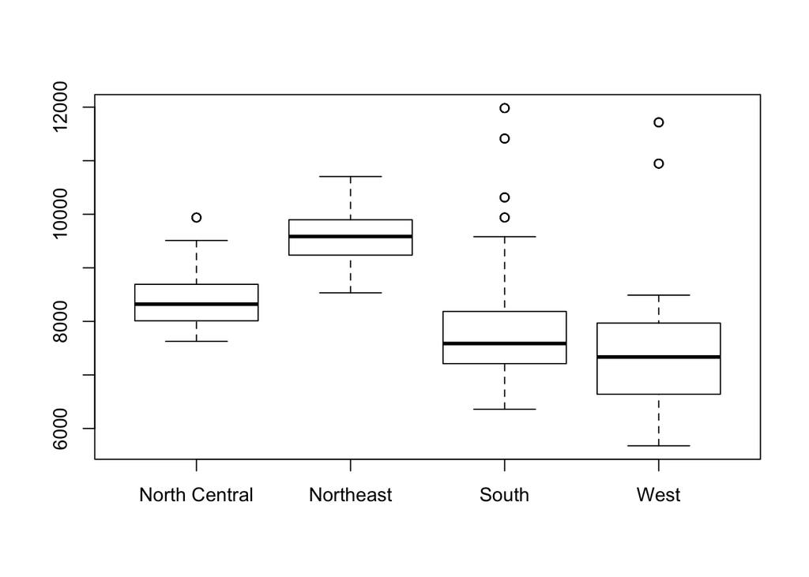

```r
## add your code here

boxplot(hc$spending_capita ~ hc$region)
```

Now that we have our data in a `tidy` format, next, we will learn about how to do this using the `ggplot2` R package in the `tidyverse`.

# Data Visualization

As you have already seen, there are many functions available in base R that can create plots (e.g. `plot()`, `boxplot()`). Others include: `hist()`, `qqplot()`, etc. These functions are great because they come with a basic installation of R and can be quite powerful when you need a quick visualization of something when you are exploring data.

We are choosing to introduce `ggplot2` because, in our opinion, it’s one of the simplest ways for beginners to create relatively complicated plots that are intuitive and aesthically pleasing.

## The `ggplot2` R package

The reasons [`ggplot2`](http://ggplot2.tidyverse.org) is generally intuitive for beginners is the use of [grammar of graphics](http://vita.had.co.nz/papers/layered-grammar.html) or the `gg` in `ggplot2`. The idea is that you can construct many sentences by learning just a few nouns, adjectives, and verbs. There are specific “words” that we will need to learn and once we do, you will be able to create (or “write”) hundreds of different plots.

The critical part to making graphics using `ggplot2` is the data needs to be in a *tidy* format. Given that we have just spend the last two lectures learning about how to work with *tidy* data, we are primed to take advantage of all that `ggplot2` has to offer!

We will show how it’s easy to pipe *tidy* data (output) as input to other functions that creates plots. This all works because we are working within the *tidyverse*.

## What is the `ggplot()` function?

As explained by Hadley Wickham:

> the grammar tells us that a statistical graphic is a mapping from data to aesthetic attributes (colour, shape, size) of geometric objects (points, lines, bars). The plot may also contain statistical transformations of the data and is drawn on a specific coordinates system.

### `ggplot2` Terminology

- **ggplot** - the main function where you specify the data set and variables to plot (this is where we define the `x` and `y` variable names)
- **geoms** - geometric objects
  - e.g. `geom_point()`, `geom_bar()`, `geom_line()`, `geom_histogram()`
- **aes** - aesthetics
  - shape, transparency, color, fill, linetype
- **scales** - define how your data will be plotted
  - continuous, discrete, log, etc

There are three ways to initialize a `ggplot()` object.

An empty ggplot object

```r
p <- ggplot()
```

A ggplot object associated with a dataset

```r
p <- hc %>%
      filter(year==2014) %>%
      ggplot()
```

or a ggplot object with a dataset and `x` and `y` defined

```r
p <- hc %>%
      filter(year==2014) %>%
      ggplot(aes(x = spending_capita, y = prop_coverage))
```

```r
p
```

### Creating your first `ggplot()`

The function `aes()` is an aesthetic mapping function inside the `ggplot()` object. We use this function to specify plot attributes (e.g. `x` and `y` variable names) that will not change as we add more layers.

Anything that goes in the `ggplot()` object becomes a global setting. From there, we use the `geom` objects to add more layers to the base `ggplot()` object. These will define what we are interested in illustrating using the data.

If you recall, our first question that we were interested in was

> 1. Is there a relationship between healthcare coverage and healthcare spending in the United States?

Before, we were using base R to create something like this:

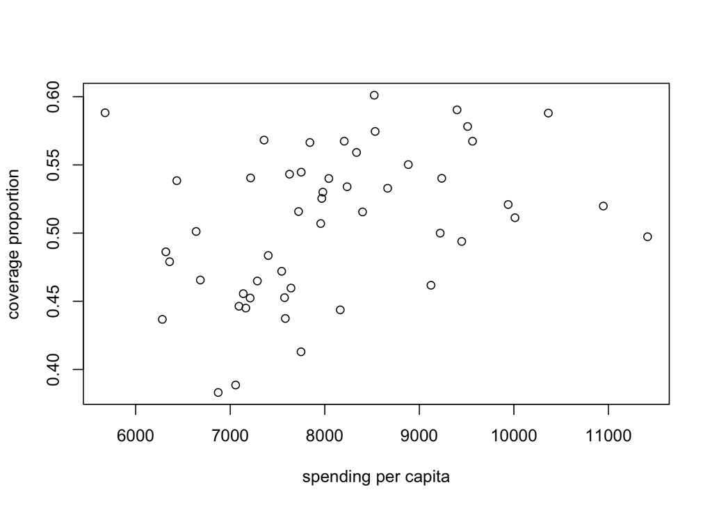

```r
hc.employer.2013 <- hc %>%
  filter(type == "Employer", year == "2013")

plot(hc.employer.2013$spending_capita,
     hc.employer.2013$prop_coverage,
     xlab = "spending per capita",
     ylab = "coverage proportion")
```

Let’s re-create this plot with `ggplot2` using the `geom_point()` geometry.

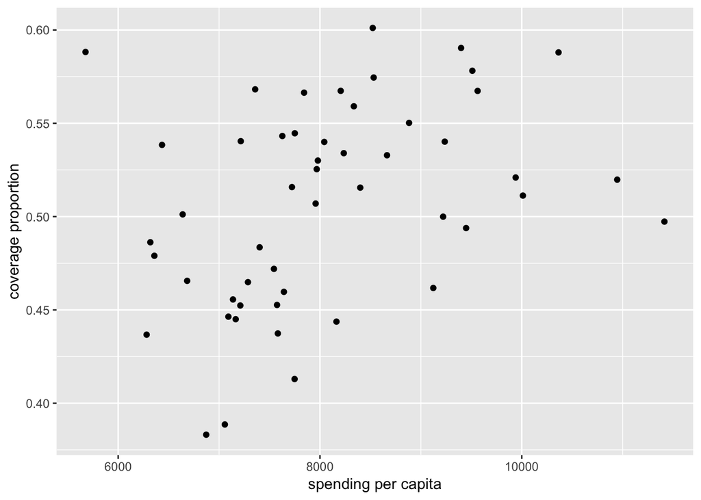

```r
p <- hc %>%
  filter(type == "Employer", year == "2013") %>%
  ggplot(aes(x = spending_capita, y = prop_coverage))
p + geom_point() +
  xlab("spending per capita") +
  ylab("coverage proportion")
```

We used the `xlab()` and `ylab()` functions in `ggplot2` to specify the x-axis and y-axis labels.

**Note**, we do not have to assign (`<-`) the plot to anything:

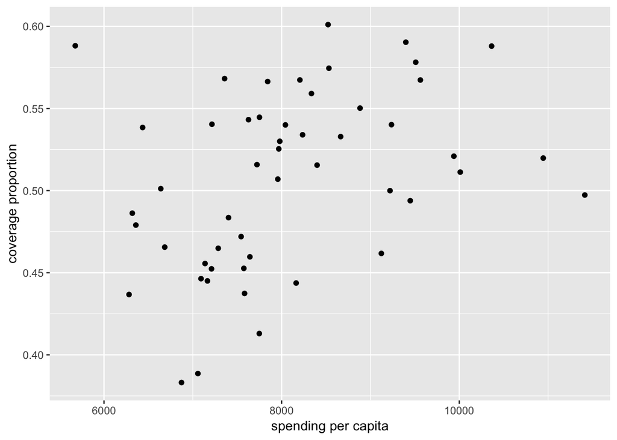

```r
hc %>%
  filter(type == "Employer", year == "2013") %>%
  ggplot(aes(x = spending_capita, y = prop_coverage)) +
  geom_point() +
  xlab("spending per capita") +
  ylab("coverage proportion")
```

It’s also simple to fit a linear regression model and plot it on top of scatter plot using the `geom_smooth()` (or `stat_smooth()`) functions.

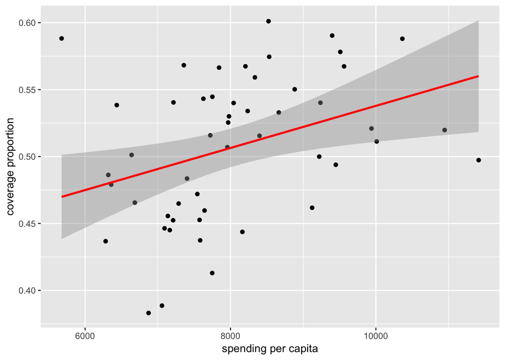

```r
hc %>%
  filter(type == "Employer", year == "2013") %>%
  ggplot(aes(x = spending_capita, y = prop_coverage)) +
  geom_point() +
  xlab("spending per capita") +
  ylab("coverage proportion") +
  geom_smooth(method = "lm", col = "red")
```

The standard error bounds are computed and included in the plot.

In the next lecture, we will explore more of `ggplot2`’s capabilities and (hopefully) finally answer the three questions we originally asked.

### `ggplot2` cheatsheet

[figure not shown]